# Importing the file as dataframe

Boxplot for independent variable against target variable for refined data

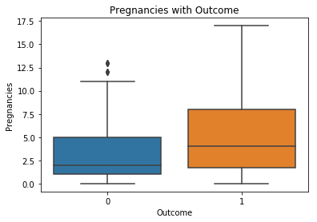

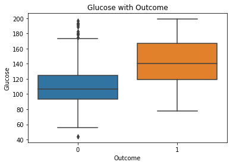

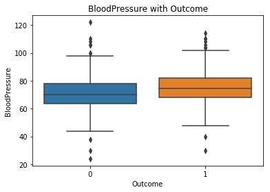

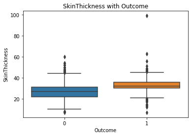

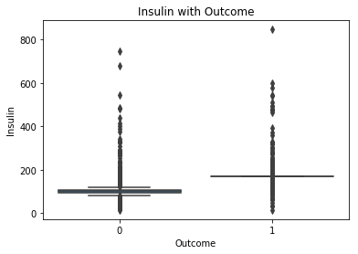

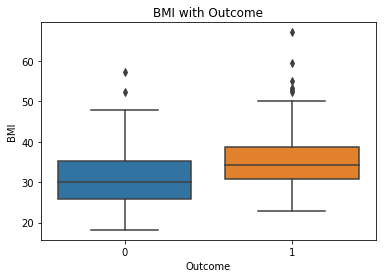

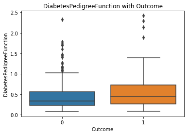

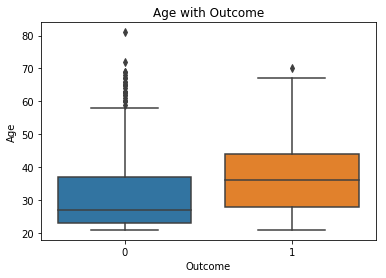

```python
col = pimadiabetes.columns[:8]
for item in col:

    plt.title( str(item) +  ' with'  +   ' Outcome')
    sns.boxplot(x = pimadiabetes.Outcome, y = pimadiabetes[item],data = pimadiabetes)
    plt.show()
```

In case of Insulin, the boxplot for the case of diabetic female after refining has reduced to a single line and all other values are outliers

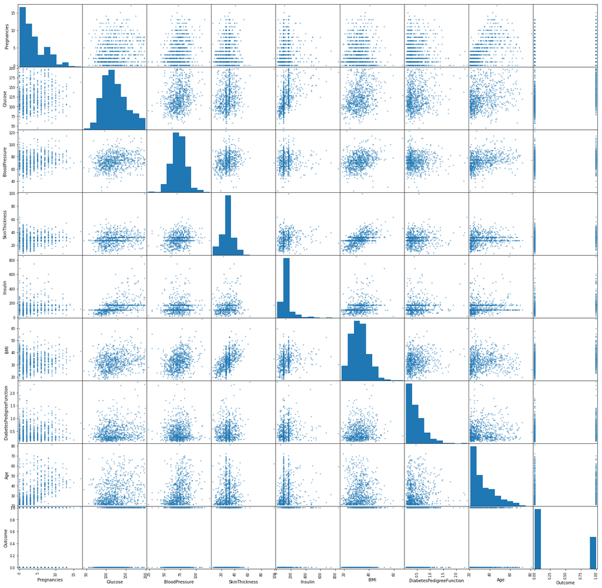

```python
# To get a view of how the  variable are scattered with respect to each other scatter matrix is drawn
from pandas.tools.plotting import scatter_matrix
p = scatter_matrix(pimadiabetes, figsize = (25,25))
```

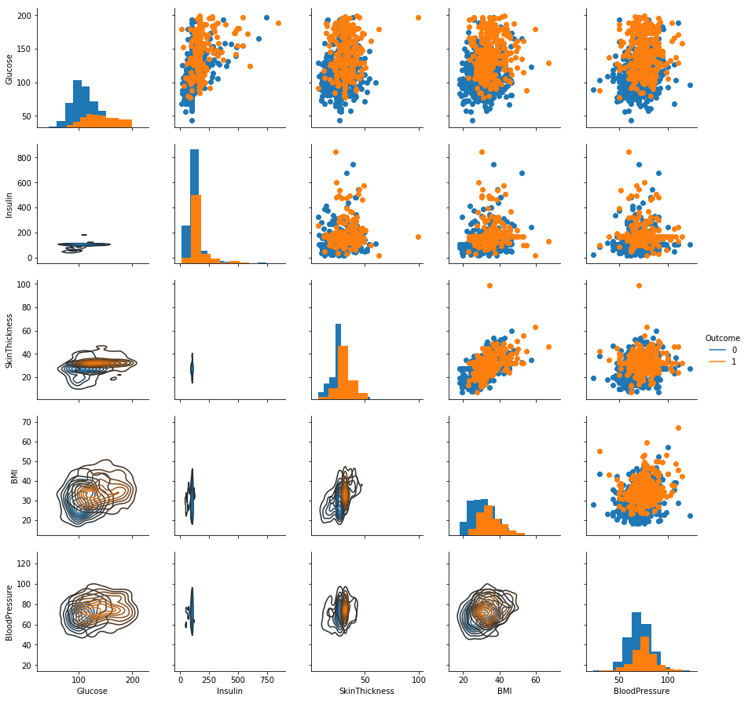

```python
g = sns.PairGrid(pimadiabetes,vars = ['Glucose','Insulin','SkinThickness','BMI','BloodPressure'],hue = 'Outcome')
g.map_diag(plt.hist)
g.map_upper(plt.scatter)
g.map_lower(sns.kdeplot)
g.add_legend()
plt.show()
```

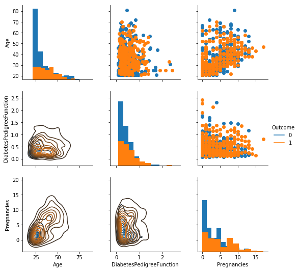

```python
g = sns.PairGrid(pimadiabetes,vars = ['Age','DiabetesPedigreeFunction','Pregnancies'],hue = 'Outcome')
g.map_diag(plt.hist)
g.map_upper(plt.scatter)
g.map_lower(sns.kdeplot)
g.add_legend()
plt.show()
```

```python
corr = diabetes.corr()
corr
```

|  | Pregnancies | Glucose | BloodPressure | SkinThickness | Insulin | BMI | DiabetesPedigreeFunction | Age | Outcome |
| --- | --- | --- | --- | --- | --- | --- | --- | --- | --- |
| Pregnancies | 1.000000 | 0.129459 | 0.141282 | -0.081672 | -0.073535 | 0.017683 | -0.033523 | 0.544341 | 0.221898 |
| Glucose | 0.129459 | 1.000000 | 0.152590 | 0.057328 | 0.331357 | 0.221071 | 0.137337 | 0.263514 | 0.466581 |
| BloodPressure | 0.141282 | 0.152590 | 1.000000 | 0.207371 | 0.088933 | 0.281805 | 0.041265 | 0.239528 | 0.065068 |
| SkinThickness | -0.081672 | 0.057328 | 0.207371 | 1.000000 | 0.436783 | 0.392573 | 0.183928 | -0.113970 | 0.074752 |
| Insulin | -0.073535 | 0.331357 | 0.088933 | 0.436783 | 1.000000 | 0.197859 | 0.185071 | -0.042163 | 0.130548 |
| BMI | 0.017683 | 0.221071 | 0.281805 | 0.392573 | 0.197859 | 1.000000 | 0.140647 | 0.036242 | 0.292695 |
| DiabetesPedigreeFunction | -0.033523 | 0.137337 | 0.041265 | 0.183928 | 0.185071 | 0.140647 | 1.000000 | 0.033561 | 0.173844 |
| Age | 0.544341 | 0.263514 | 0.239528 | -0.113970 | -0.042163 | 0.036242 | 0.033561 | 1.000000 | 0.238356 |
| Outcome | 0.221898 | 0.466581 | 0.065068 | 0.074752 | 0.130548 | 0.292695 | 0.173844 | 0.238356 | 1.000000 |

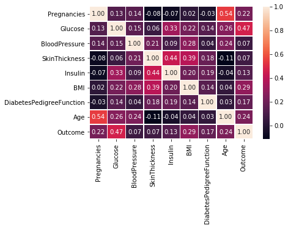

```python
sns.heatmap(corr,annot = True,linewidth = 0.5,fmt = '.2f')
```

The maximum value of correilation in the heatmap is 0.54, which is not an healthy correlation to say the variables are redundant.

Predicting whether a person is diabetic using decision tree classifier

```python
parameters = list(pimadiabetes.columns[:8])
parameters
```

```
['Pregnancies',
 'Glucose',
 'BloodPressure',
 'SkinThickness',
 'Insulin',
 'BMI',
 'DiabetesPedigreeFunction',
 'Age']
```

```python
Y =pimadiabetes["Outcome"]
X = pimadiabetes[parameters]
clf = tree.DecisionTreeClassifier()
clf = clf.fit(X,Y)
```

```python
print (clf.predict([[2,80,110,20,350,35,0.340,30]]))
```

```
[0]
```

```python
print(clf.predict([[6,100,80,45,200,25,.25,30]]))
```

```
[0]
```

```python
print(clf.predict([[0,100,80,45,200,25,.25,30]]))
```

```
[0]
```

CONCLUSIONS

1. The pima indian diabetes dataset has many '0' values which are treated as 'missing' values and replaced with median value calculated after grouping by outcome
2. The effect of replacing the '0' values with median is studied by plotting histograms and boxplots for the refined and unrefined data
3. Univariate and bivariate analysis is done by scatter plots and boxplots
4. Plotting of different independent variable with the target variable is done
5. The count of non-diabetic women is more than the diabetic women as the data is largely available for young women.
6. More than 50% of women greater than 50yrs of age are diabetic and about 21.4% women are diabetic who are below 30yrs of age
7. No two variables are correlated in a such a manner so as to call them redundant.
8. Predicting the target variable with a decisiontreeclassifier is tried